# Cyclistic

DHARMIK

2022-09-15

# Import, clean and analyze

## Setting up environment

Setting up R environment by loading packages whose names are as follows:

- tidyverse
- rmarkdown
- janitor

```r
library(tidyverse)
library(lubridate)
library(rmarkdown)
library(janitor)
```

## Importing the datasets in RStudio

```r
`202105` <- read.csv("D:/Project/Analytics/cyclystic/202105.csv")
`202106` <- read.csv("D:/Project/Analytics/cyclystic/202106.csv")
`202107` <- read.csv("D:/Project/Analytics/cyclystic/202107.csv")
`202108` <- read.csv("D:/Project/Analytics/cyclystic/202108.csv")
`202109` <- read.csv("D:/Project/Analytics/cyclystic/202109.csv")
`202110` <- read.csv("D:/Project/Analytics/cyclystic/202110.csv")
`202111` <- read.csv("D:/Project/Analytics/cyclystic/202111.csv")
`202112` <- read.csv("D:/Project/Analytics/cyclystic/202112.csv")
`202201` <- read.csv("D:/Project/Analytics/cyclystic/202201.csv")
`202202` <- read.csv("D:/Project/Analytics/cyclystic/202202.csv")
`202203` <- read.csv("D:/Project/Analytics/cyclystic/202203.csv")
`202204` <- read.csv("D:/Project/Analytics/cyclystic/202204.csv")
`202205` <- read.csv("D:/Project/Analytics/cyclystic/202205.csv")
```

## Merging datasets and observe it

```r
cyclistic_data <- rbind(`202105`, `202106`, `202107`, `202108`, `202109`, `202110`, `202111`, `202112`,`202201`, `202202`, `202203`, `202204`,`202205`)
View(cyclistic_data)

colnames(cyclistic_data)  #List of column names
```

```
##  [1] "ride_id"            "rideable_type"      "started_at"
##  [4] "ended_at"           "start_station_name" "start_station_id"
##  [7] "end_station_name"   "end_station_id"     "start_lat"
## [10] "start_lng"          "end_lat"            "end_lng"
## [13] "member_casual"
```

```r
dim(cyclistic_data)  #Dimensions of the data frame
```

```
## [1] 6392409      13
```

```r
head(cyclistic_data)  #See the rows of data frame.
```

```
##            ride_id rideable_type          started_at            ended_at
## 1 C809ED75D6160B2A electric_bike 2021-05-30 11:58:15 2021-05-30 12:10:39
## 2 DD59FDCE0ACACAF3 electric_bike 2021-05-30 11:29:14 2021-05-30 12:14:09
## 3 0AB83CB88C43EFC2 electric_bike 2021-05-30 14:24:01 2021-05-30 14:25:13
## 4 7881AC6D39110C60 electric_bike 2021-05-30 14:25:51 2021-05-30 14:41:04
## 5 853FA701B4582BAF electric_bike 2021-05-30 18:15:39 2021-05-30 18:22:32
## 6 F5E63DFD96B2A737 electric_bike 2021-05-30 11:33:41 2021-05-30 11:57:17
##   start_station_name start_station_id end_station_name end_station_id start_lat
## 1                                                                         41.90
## 2                                                                         41.88
## 3                                                                         41.92
## 4                                                                         41.92
## 5                                                                         41.94
## 6                                                                         41.88
##   start_lng end_lat end_lng member_casual
## 1    -87.63   41.89  -87.61        casual
## 2    -87.62   41.79  -87.58        casual
## 3    -87.70   41.92  -87.70        casual
## 4    -87.70   41.94  -87.69        casual
## 5    -87.69   41.94  -87.70        casual
## 6    -87.63   41.89  -87.62        casual
```

```r
str(cyclistic_data)  #See list of columns and data types
```

```
## 'data.frame':    6392409 obs. of  13 variables:
##  $ ride_id           : chr  "C809ED75D6160B2A" "DD59FDCE0ACACAF3" "0AB83CB88C43EFC2" "7881AC6D39110C60" ...
##  $ rideable_type     : chr  "electric_bike" "electric_bike" "electric_bike" "electric_bike" ...
##  $ started_at        : chr  "2021-05-30 11:58:15" "2021-05-30 11:29:14" "2021-05-30 14:24:01" "2021-05-30 14:25:51" ...
##  $ ended_at          : chr  "2021-05-30 12:10:39" "2021-05-30 12:14:09" "2021-05-30 14:25:13" "2021-05-30 14:41:04" ...
##  $ start_station_name: chr  "" "" "" "" ...
##  $ start_station_id  : chr  "" "" "" "" ...
##  $ end_station_name  : chr  "" "" "" "" ...
##  $ end_station_id    : chr  "" "" "" "" ...
##  $ start_lat         : num  41.9 41.9 41.9 41.9 41.9 ...
##  $ start_lng         : num  -87.6 -87.6 -87.7 -87.7 -87.7 ...
##  $ end_lat           : num  41.9 41.8 41.9 41.9 41.9 ...
##  $ end_lng           : num  -87.6 -87.6 -87.7 -87.7 -87.7 ...
##  $ member_casual     : chr  "casual" "casual" "casual" "casual" ...
```

```r
summary(cyclistic_data)  #Statistical summary of data
```

```
##    ride_id          rideable_type       started_at          ended_at
##  Length:6392409     Length:6392409     Length:6392409     Length:6392409
##  Class :character   Class :character   Class :character   Class :character
##  Mode  :character   Mode  :character   Mode  :character   Mode  :character
##
##
##
##
##  start_station_name start_station_id   end_station_name   end_station_id
##  Length:6392409     Length:6392409     Length:6392409     Length:6392409
##  Class :character   Class :character   Class :character   Class :character
##  Mode  :character   Mode  :character   Mode  :character   Mode  :character
##
##
##
##
##    start_lat       start_lng         end_lat         end_lng
##  Min.   :41.64   Min.   :-87.84   Min.   :41.39   Min.   :-88.97
##  1st Qu.:41.88   1st Qu.:-87.66   1st Qu.:41.88   1st Qu.:-87.66
##  Median :41.90   Median :-87.64   Median :41.90   Median :-87.64
##  Mean   :41.90   Mean   :-87.65   Mean   :41.90   Mean   :-87.65
##  3rd Qu.:41.93   3rd Qu.:-87.63   3rd Qu.:41.93   3rd Qu.:-87.63
##  Max.   :45.64   Max.   :-73.80   Max.   :42.17   Max.   :-87.49
##                                   NA's   :5488    NA's   :5488
##  member_casual
##  Length:6392409
##  Class :character
##  Mode  :character
##
##
##
##
```

## Create columns named date, month, day, year and day of week

```r
cyclistic_data$date <- as.Date(cyclistic_data$started_at)
cyclistic_data$month <- format(as.Date(cyclistic_data$date), "%m")
cyclistic_data$day <- format(as.Date(cyclistic_data$date), "%d")
cyclistic_data$year <- format(as.Date(cyclistic_data$date), "%Y")
cyclistic_data$day_of_week <- format(as.Date(cyclistic_data$date), "%A")
```

## Find total time and convert it into numeric

```r
cyclistic_data$total_time <- difftime(cyclistic_data$ended_at,cyclistic_data$started_at)
str(cyclistic_data)
```

```
## 'data.frame':    6392409 obs. of  19 variables:
##  $ ride_id           : chr  "C809ED75D6160B2A" "DD59FDCE0ACACAF3" "0AB83CB88C43EFC2" "7881AC6D39110C60" ...
##  $ rideable_type     : chr  "electric_bike" "electric_bike" "electric_bike" "electric_bike" ...
##  $ started_at        : chr  "2021-05-30 11:58:15" "2021-05-30 11:29:14" "2021-05-30 14:24:01" "2021-05-30 14:25:51" ...
##  $ ended_at          : chr  "2021-05-30 12:10:39" "2021-05-30 12:14:09" "2021-05-30 14:25:13" "2021-05-30 14:41:04" ...
##  $ start_station_name: chr  "" "" "" "" ...
##  $ start_station_id  : chr  "" "" "" "" ...
##  $ end_station_name  : chr  "" "" "" "" ...
##  $ end_station_id    : chr  "" "" "" "" ...
##  $ start_lat         : num  41.9 41.9 41.9 41.9 41.9 ...
##  $ start_lng         : num  -87.6 -87.6 -87.7 -87.7 -87.7 ...
##  $ end_lat           : num  41.9 41.8 41.9 41.9 41.9 ...
##  $ end_lng           : num  -87.6 -87.6 -87.7 -87.7 -87.7 ...
##  $ member_casual     : chr  "casual" "casual" "casual" "casual" ...
##  $ date              : Date, format: "2021-05-30" "2021-05-30" ...
##  $ month             : chr  "05" "05" "05" "05" ...
##  $ day               : chr  "30" "30" "30" "30" ...
##  $ year              : chr  "2021" "2021" "2021" "2021" ...
##  $ day_of_week       : chr  "Sunday" "Sunday" "Sunday" "Sunday" ...
##  $ total_time        : 'difftime' num  744 2695 72 913 ...
##   ..- attr(*, "units")= chr "secs"
```

```r
cyclistic_data$total_time <- as.numeric(as.character(cyclistic_data$total_time))
str(cyclistic_data)
```

```
## 'data.frame':    6392409 obs. of  19 variables:
##  $ ride_id           : chr  "C809ED75D6160B2A" "DD59FDCE0ACACAF3" "0AB83CB88C43EFC2" "7881AC6D39110C60" ...
##  $ rideable_type     : chr  "electric_bike" "electric_bike" "electric_bike" "electric_bike" ...
##  $ started_at        : chr  "2021-05-30 11:58:15" "2021-05-30 11:29:14" "2021-05-30 14:24:01" "2021-05-30 14:25:51" ...
##  $ ended_at          : chr  "2021-05-30 12:10:39" "2021-05-30 12:14:09" "2021-05-30 14:25:13" "2021-05-30 14:41:04" ...
##  $ start_station_name: chr  "" "" "" "" ...
##  $ start_station_id  : chr  "" "" "" "" ...
##  $ end_station_name  : chr  "" "" "" "" ...
##  $ end_station_id    : chr  "" "" "" "" ...
##  $ start_lat         : num  41.9 41.9 41.9 41.9 41.9 ...
##  $ start_lng         : num  -87.6 -87.6 -87.7 -87.7 -87.7 ...
##  $ end_lat           : num  41.9 41.8 41.9 41.9 41.9 ...
##  $ end_lng           : num  -87.6 -87.6 -87.7 -87.7 -87.7 ...
##  $ member_casual     : chr  "casual" "casual" "casual" "casual" ...
##  $ date              : Date, format: "2021-05-30" "2021-05-30" ...
##  $ month             : chr  "05" "05" "05" "05" ...
##  $ day               : chr  "30" "30" "30" "30" ...
##  $ year              : chr  "2021" "2021" "2021" "2021" ...
##  $ day_of_week       : chr  "Sunday" "Sunday" "Sunday" "Sunday" ...
##  $ total_time        : num  744 2695 72 913 413 ...
```

## Remove NA values and total time less than zero

```r
cyclistic_data2 <- cyclistic_data[!(cyclistic_data$start_station_name == "HQ QR" | cyclistic_data$total_time<0),]
```

## Finding total time, mid. point of total time, longest ride, shortest ride and summary of cyclistic dataset

```r
mean(cyclistic_data2$total_time) #average total_time
```

```
## [1] 1268.106
```

```r
median(cyclistic_data2$total_time) #midpoint number in the ascending array of total_time
```

```
## [1] 691
```

```r
max(cyclistic_data2$total_time) #longest ride
```

```
## [1] 3356649
```

```r
min(cyclistic_data2$total_time) #shortest ride
```

```
## [1] 0
```

```r
summary(cyclistic_data2$total_time)
```

```
##    Min. 1st Qu.  Median    Mean 3rd Qu.    Max.
##       0     386     691    1268    1259 3356649
```

## Compare members and casual users

```r
aggregate(cyclistic_data2$total_time ~ cyclistic_data2$member_casual, FUN = mean)
```

```
##   cyclistic_data2$member_casual cyclistic_data2$total_time
## 1                        casual                  1874.9993
## 2                        member                   790.0134
```

```r
aggregate(cyclistic_data2$total_time ~ cyclistic_data2$member_casual, FUN = median)
```

```
##   cyclistic_data2$member_casual cyclistic_data2$total_time
## 1                        casual                        932
## 2                        member                        553
```

```r
aggregate(cyclistic_data2$total_time ~ cyclistic_data2$member_casual, FUN = max)
```

```
##   cyclistic_data2$member_casual cyclistic_data2$total_time
## 1                        casual                    3356649
## 2                        member                      93594
```

```r
aggregate(cyclistic_data2$total_time ~ cyclistic_data2$member_casual, FUN = min)
```

```
##   cyclistic_data2$member_casual cyclistic_data2$total_time
## 1                        casual                          0
## 2                        member                          0
```

## Average ride time by each day for members vs casual users

```r
aggregate(cyclistic_data2$total_time ~ cyclistic_data2$member_casual + cyclistic_data2$day_of_week, FUN = mean)
```

```
##    cyclistic_data2$member_casual cyclistic_data2$day_of_week
## 1                         casual                      Friday
## 2                         member                      Friday
## 3                         casual                      Monday
## 4                         member                      Monday
## 5                         casual                    Saturday
## 6                         member                    Saturday
## 7                         casual                      Sunday
## 8                         member                      Sunday
## 9                         casual                    Thursday
## 10                        member                    Thursday
## 11                        casual                     Tuesday
## 12                        member                     Tuesday
## 13                        casual                   Wednesday
## 14                        member                   Wednesday
##    cyclistic_data2$total_time
## 1                   1753.8561
## 2                    772.3751
## 3                   1875.6017
## 4                    767.7337
## 5                   2047.4435
## 6                    886.4354
## 7                   2197.8841
## 8                    899.7936
## 9                   1681.5611
## 10                   750.4451
## 11                  1589.7621
## 12                   738.9039
## 13                  1619.4900
## 14                   744.4944
```

## Fix the order of the days of the week and rerun

```r
cyclistic_data2$day_of_week <- ordered(cyclistic_data2$day_of_week,
                      levels=c("Sunday", "Monday", "Tuesday", "Wednesday", "Thursday", "Friday", "Saturday"))
```

```r
aggregate(cyclistic_data2$total_time ~ cyclistic_data2$member_casual + cyclistic_data2$day_of_week, FUN = mean)
```

```
##    cyclistic_data2$member_casual cyclistic_data2$day_of_week
## 1                         casual                      Sunday
## 2                         member                      Sunday
## 3                         casual                      Monday
## 4                         member                      Monday
## 5                         casual                     Tuesday
## 6                         member                     Tuesday
## 7                         casual                   Wednesday
## 8                         member                   Wednesday
## 9                         casual                    Thursday
## 10                        member                    Thursday
## 11                        casual                      Friday
## 12                        member                      Friday
## 13                        casual                    Saturday
## 14                        member                    Saturday
##    cyclistic_data2$total_time
## 1                   2197.8841
## 2                    899.7936
## 3                   1875.6017
## 4                    767.7337
## 5                   1589.7621
## 6                    738.9039
## 7                   1619.4900
## 8                    744.4944
## 9                   1681.5611
## 10                   750.4451
## 11                  1753.8561
## 12                   772.3751
## 13                  2047.4435
## 14                   886.4354
```

# Visualization

We visualize the relationships in si different ways:

- Weekday Vs. No. of Rides and member_casual as fill
- Weekday Vs. No. of Rides and rideable tipe as fill
- Weekday Vs. No. of Rides by using facet_grid()
- Weekday Vs. Avg_duration and member_casual as fill
- Weekday Vs. Avg_duration and rideable tipe as fill
- Weekday Vs. Avg_duration by using facet_grid()

## Analyze data by type and weekday, and visualize the number of rides by rider type

For analysis we create weekday field by using wday() and gorup it by usertype and weekday. Then we calculate the number of rides and average duration. At the we visualize our analysis by using ggplot2 package.

### 1. Weekday Vs. No. of Rides and member_casual as fill

We plot weekday and no. of rides by member_casual.

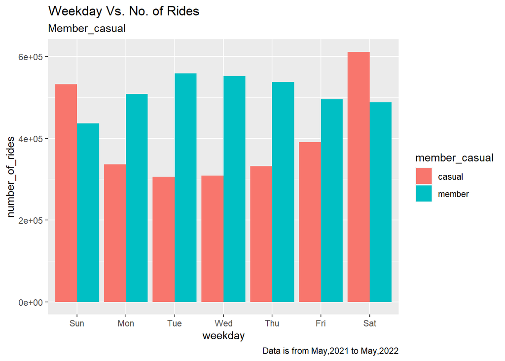

```r
cyclistic_data2 %>%
  mutate(weekday = wday(started_at, label = TRUE)) %>%  #creates weekday field using wday()
  group_by(member_casual, weekday) %>%  #grouping by usertype and weekday
  summarise(number_of_rides = n()                           #calculate the number of rides and average duration
            ,avg_duration = mean(total_time)) %>%       # calculates the average duration
  arrange(member_casual, weekday) %>%
  ggplot(aes(x = weekday, y = number_of_rides, fill = member_casual)) +
  geom_col(position = "dodge") +
  labs(title = "Weekday Vs. No. of Rides",
       subtitle = "Member_casual",
       caption = "Data is from May,2021 to May,2022")
```

### 2. Weekday Vs. No. of Rides and rideable tipe as fill

We plot weekday and no. of rides by rideable_type.

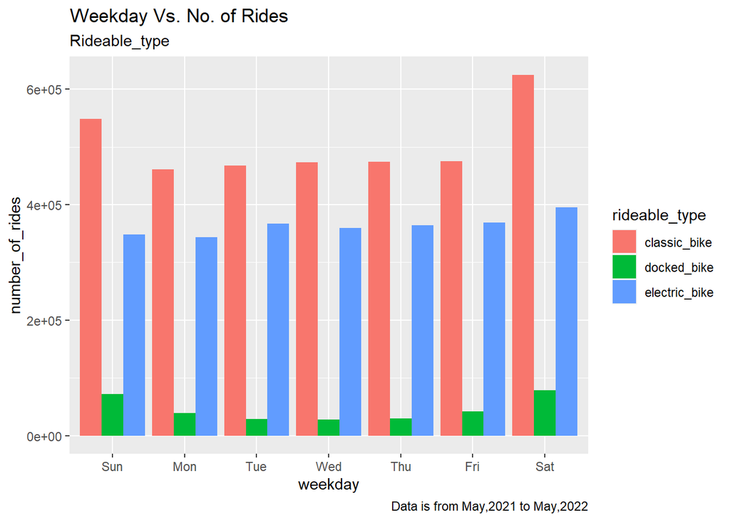

```r
cyclistic_data2 %>%
  mutate(weekday = wday(started_at, label = TRUE)) %>%
  group_by(rideable_type, weekday) %>%
  summarise(number_of_rides = n()
            ,avg_duration = mean(total_time)) %>%
  arrange(rideable_type, weekday) %>%
  ggplot(aes(x = weekday, y = number_of_rides, fill = rideable_type)) +
  geom_col(position = "dodge") +
  labs(title = "Weekday Vs. No. of Rides",
       subtitle = "Rideable_type",
       caption = "Data is from May,2021 to May,2022")
```

### 3. Weekday Vs. No. of Rides by using facet_grid()

We plot weekday and no. of rides and look at the breakdown by rideable_type and member_casual.

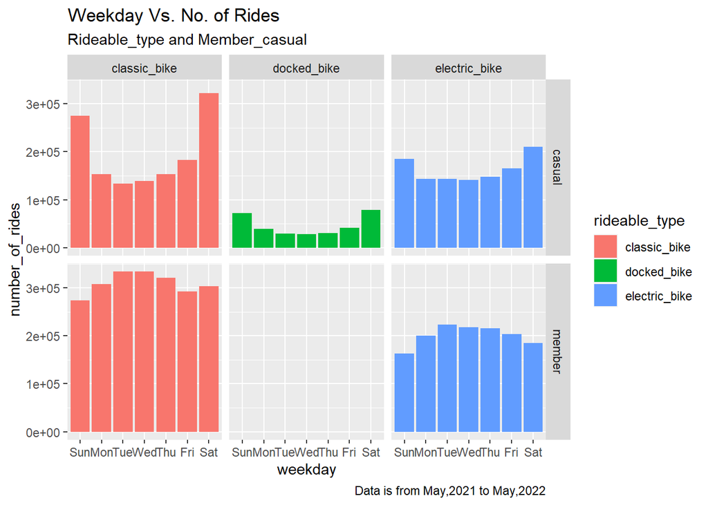

```r
cyclistic_data2 %>%
  mutate(weekday = wday(started_at, label = TRUE)) %>%
  group_by(rideable_type, member_casual, weekday) %>%
  summarise(number_of_rides = n()
            ,avg_duration = mean(total_time)) %>%
  arrange(rideable_type, member_casual, weekday) %>%
  ggplot(aes(x = weekday, y = number_of_rides, fill = rideable_type)) +
  geom_col(position = "dodge") +
  facet_grid(member_casual ~ rideable_type) +
  labs(title = "Weekday Vs. No. of Rides",
       subtitle = "Rideable_type and Member_casual",
       caption = "Data is from May,2021 to May,2022")
```

### 4. Weekday Vs. Avg_duration and member_casual as fill

We plot Weekday Vs. Avg_duration by member_casual.

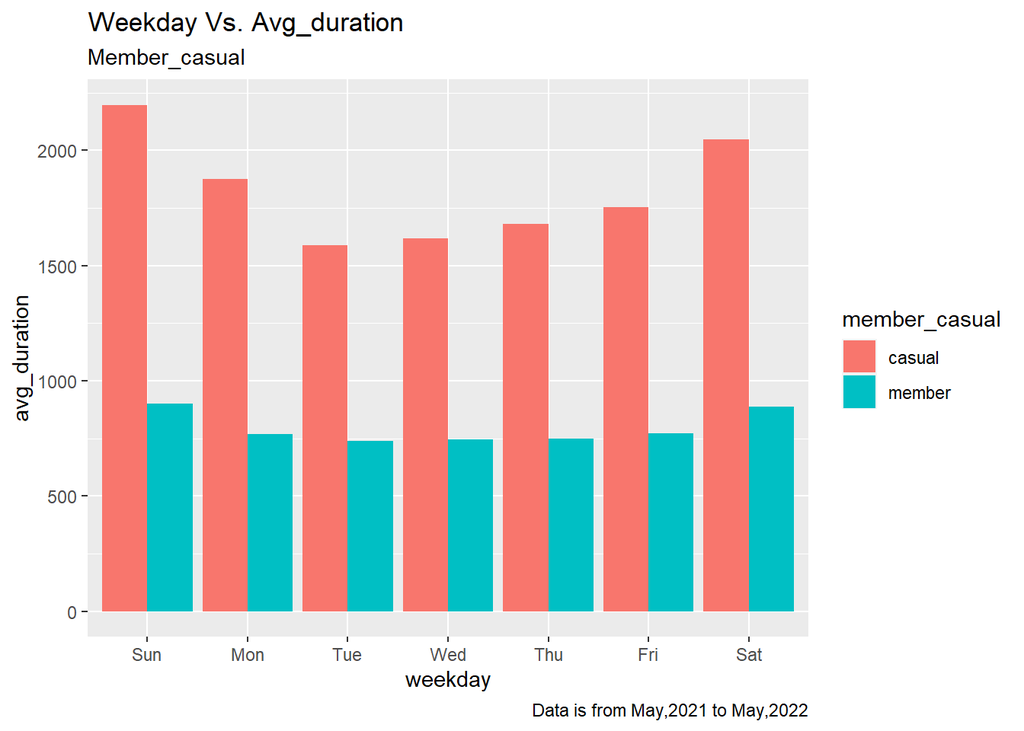

```r
cyclistic_data2%>%
  mutate(weekday = wday(started_at, label = TRUE)) %>%
  group_by(member_casual, weekday) %>%
  summarise(number_of_rides = n()
            ,avg_duration = mean(total_time)) %>%
  arrange(member_casual, weekday)  %>%
  ggplot(aes(x = weekday, y = avg_duration, fill = member_casual)) +
  geom_col(position = "dodge") +
  labs(title = "Weekday Vs. Avg_duration",
       subtitle = "Member_casual",
       caption = "Data is from May,2021 to May,2022")
```

### 5. Weekday Vs. Avg_duration and rideable tipe as fill

We plot Weekday Vs. Avg_duration by rideable_type.

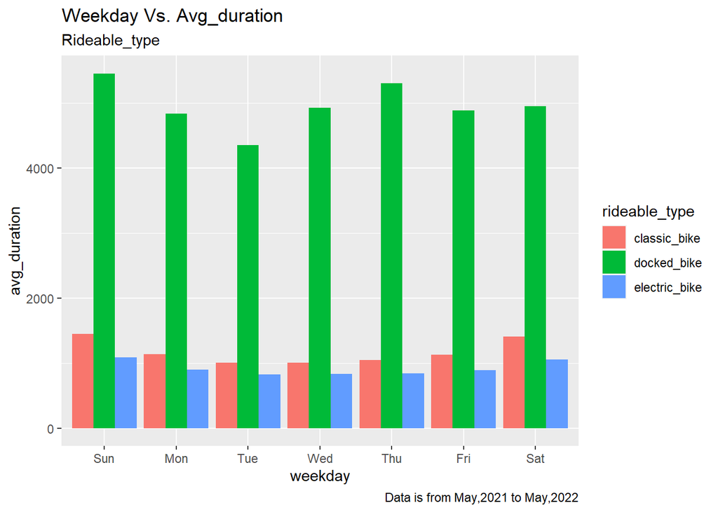

```r
cyclistic_data2%>%
  mutate(weekday = wday(started_at, label = TRUE)) %>%
  group_by(rideable_type, weekday) %>%
  summarise(number_of_rides = n()
            ,avg_duration = mean(total_time)) %>%
  arrange(rideable_type, weekday)  %>%
  ggplot(aes(x = weekday, y = avg_duration, fill = rideable_type)) +
  geom_col(position = "dodge") +
  labs(title = "Weekday Vs. Avg_duration",
       subtitle = "Rideable_type",
       caption = "Data is from May,2021 to May,2022")
```

### 6. Weekday Vs. Avg_duration by using facet_grid()

We plot Weekday Vs. Avg_duration and look at the breakdown by rideable_type and member_casual.

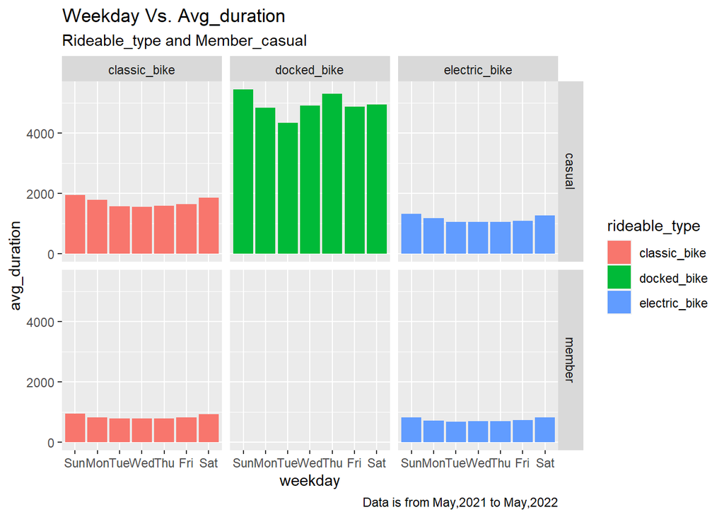

```r
cyclistic_data2%>%
  mutate(weekday = wday(started_at, label = TRUE)) %>%
  group_by(rideable_type, member_casual, weekday) %>%
  summarise(number_of_rides = n()
            ,avg_duration = mean(total_time)) %>%
  arrange(rideable_type, member_casual, weekday)  %>%
  ggplot(aes(x = weekday, y = avg_duration, fill = rideable_type)) +
  geom_col(position = "dodge") +
  facet_grid(member_casual ~ rideable_type) +
  labs(title = "Weekday Vs. Avg_duration",
       subtitle = "Rideable_type and Member_casual",
       caption = "Data is from May,2021 to May,2022")
```

## Creating dataframe named counts

In this dataframe, we summarize the total time by member_casual and day_of_week.

```r
counts <- aggregate(cyclistic_data2$total_time ~ cyclistic_data2$member_casual +
          cyclistic_data2$day_of_week, FUN = mean)
```

## Creating csv file to store the dataframe called counts

```r
write.csv(counts, file = 'D:/Project/Analytics/cyclystic/Save/avg_duration.csv')
```